# David Weiss Final Project

First I made sure to library some commonly used packages in this course. Not only will this allow me to create graphs, but I will be able to code in the correct syntax.

```r
library(DataComputing)
library(tidyverse)
library(mosaic)
library(ggplot2)
library(maps)
rm(list = ls())
```

I accessed my data from Kaggle. The [dataset](https://www.kaggle.com/karangadiya/fifa19) involves all of the FIFA players from FIFA 19. Given my data set and curiosity, I decided upon my research question; What factors describe the top soccer players in FIFA?

### Upload Data Sets

```r
### Using file.choose we store the csv address in dataset
Orig_Fifa_data <- read_csv("/Users/davidweiss/Desktop/Fall 2019/Stat 184/Final Project/FIFA DATA.csv")
head(Orig_Fifa_data)
```

| X1 | ID | Name | Age | Photo | Nationality | Flag | Overall | Potential | Club | Club Logo | Value | Wage | Special | Preferred Foot | International Reputation | Weak Foot | Skill Moves | Work Rate | Body Type | Real Face | Position | Jersey Number | Joined | Loaned From | Contract Valid Until | Height | Weight | LS | ST | … |
| --- | --- | --- | --- | --- | --- | --- | --- | --- | --- | --- | --- | --- | --- | --- | --- | --- | --- | --- | --- | --- | --- | --- | --- | --- | --- | --- | --- | --- | --- | --- |
| 0 | 158023 | L. Messi | 31 | https://cdn.sofifa.org/players/4/19/158023.png | Argentina | https://cdn.sofifa.org/flags/52.png | 94 | 94 | FC Barcelona | https://cdn.sofifa.org/teams/2/light/241.png | \xf3110.5M | \xf3565K | 2202 | Left | 5 | 4 | 4 | Medium/ Medium | Messi | Yes | RF | 10 | 1-Jul-04 | NA | 2021 | 5'7 | 159lbs | 88+2 | 88+2 | … |
| 1 | 20801 | Cristiano Ronaldo | 33 | https://cdn.sofifa.org/players/4/19/20801.png | Portugal | https://cdn.sofifa.org/flags/38.png | 94 | 94 | Juventus | https://cdn.sofifa.org/teams/2/light/45.png | \xf377M | \xf3405K | 2228 | Right | 5 | 4 | 5 | High/ Low | C. Ronaldo | Yes | ST | 7 | 10-Jul-18 | NA | 2022 | 6'2 | 183lbs | 91+3 | 91+3 | … |
| 2 | 190871 | Neymar Jr | 26 | https://cdn.sofifa.org/players/4/19/190871.png | Brazil | https://cdn.sofifa.org/flags/54.png | 92 | 93 | Paris Saint-Germain | https://cdn.sofifa.org/teams/2/light/73.png | \xf3118.5M | \xf3290K | 2143 | Right | 5 | 5 | 5 | High/ Medium | Neymar | Yes | LW | 10 | 3-Aug-17 | NA | 2022 | 5'9 | 150lbs | 84+3 | 84+3 | … |
| 3 | 193080 | De Gea | 27 | https://cdn.sofifa.org/players/4/19/193080.png | Spain | https://cdn.sofifa.org/flags/45.png | 91 | 93 | Manchester United | https://cdn.sofifa.org/teams/2/light/11.png | \xf372M | \xf3260K | 1471 | Right | 4 | 3 | 1 | Medium/ Medium | Lean | Yes | GK | 1 | 1-Jul-11 | NA | 2020 | 6'4 | 168lbs | NA | NA | … |
| 4 | 192985 | K. De Bruyne | 27 | https://cdn.sofifa.org/players/4/19/192985.png | Belgium | https://cdn.sofifa.org/flags/7.png | 91 | 92 | Manchester City | https://cdn.sofifa.org/teams/2/light/10.png | \xf3102M | \xf3355K | 2281 | Right | 4 | 5 | 4 | High/ High | Normal | Yes | RCM | 7 | 30-Aug-15 | NA | 2023 | 5'11 | 154lbs | 82+3 | 82+3 | … |
| 5 | 183277 | E. Hazard | 27 | https://cdn.sofifa.org/players/4/19/183277.png | Belgium | https://cdn.sofifa.org/flags/7.png | 91 | 91 | Chelsea | https://cdn.sofifa.org/teams/2/light/5.png | \xf393M | \xf3340K | 2142 | Right | 4 | 4 | 4 | High/ Medium | Normal | Yes | LF | 10 | 1-Jul-12 | NA | 2020 | 5'8 | 163lbs | 83+3 | 83+3 | … |

```r
str(Orig_Fifa_data)
```

```
Classes ‘spec_tbl_df’, ‘tbl_df’, ‘tbl’ and 'data.frame':    18207 obs. of  89 variables:
 $ X1                      : num  0 1 2 3 4 5 6 7 8 9 ...
 $ ID                      : num  158023 20801 190871 193080 192985 ...
 $ Name                    : chr  "L. Messi" "Cristiano Ronaldo" "Neymar Jr" "De Gea" ...
 $ Age                     : num  31 33 26 27 27 27 32 31 32 25 ...
 $ Photo                   : chr  "https://cdn.sofifa.org/players/4/19/158023.png" "https://cdn.sofifa.org/players/4/19/20801.png" "https://cdn.sofifa.org/players/4/19/190871.png" "https://cdn.sofifa.org/players/4/19/193080.png" ...
 $ Nationality             : chr  "Argentina" "Portugal" "Brazil" "Spain" ...
 $ Flag                    : chr  "https://cdn.sofifa.org/flags/52.png" "https://cdn.sofifa.org/flags/38.png" "https://cdn.sofifa.org/flags/54.png" "https://cdn.sofifa.org/flags/45.png" ...
 $ Overall                 : num  94 94 92 91 91 91 91 91 91 90 ...
 $ Potential               : num  94 94 93 93 92 91 91 91 91 93 ...
 $ Club                    : chr  "FC Barcelona" "Juventus" "Paris Saint-Germain" "Manchester United" ...
 $ Club Logo               : chr  "https://cdn.sofifa.org/teams/2/light/241.png" "https://cdn.sofifa.org/teams/2/light/45.png" "https://cdn.sofifa.org/teams/2/light/73.png" "https://cdn.sofifa.org/teams/2/light/11.png" ...
 $ Value                   : chr  "\xf3110.5M" "\xf377M" "\xf3118.5M" "\xf372M" ...
 $ Wage                    : chr  "\xf3565K" "\xf3405K" "\xf3290K" "\xf3260K" ...
 $ Special                 : num  2202 2228 2143 1471 2281 ...
 $ Preferred Foot          : chr  "Left" "Right" "Right" "Right" ...
 $ International Reputation: num  5 5 5 4 4 4 4 5 4 3 ...
 $ Weak Foot               : num  4 4 5 3 5 4 4 4 3 3 ...
 $ Skill Moves             : num  4 5 5 1 4 4 4 3 3 1 ...
 $ Work Rate               : chr  "Medium/ Medium" "High/ Low" "High/ Medium" "Medium/ Medium" ...
 $ Body Type               : chr  "Messi" "C. Ronaldo" "Neymar" "Lean" ...
 $ Real Face               : chr  "Yes" "Yes" "Yes" "Yes" ...
 $ Position                : chr  "RF" "ST" "LW" "GK" ...
 $ Jersey Number           : num  10 7 10 1 7 10 10 9 15 1 ...
 $ Joined                  : chr  "1-Jul-04" "10-Jul-18" "3-Aug-17" "1-Jul-11" ...
 $ Loaned From             : chr  NA NA NA NA ...
 $ Contract Valid Until    : chr  "2021" "2022" "2022" "2020" ...
 $ Height                  : chr  "5'7" "6'2" "5'9" "6'4" ...
 $ Weight                  : chr  "159lbs" "183lbs" "150lbs" "168lbs" ...
 $ LS                      : chr  "88+2" "91+3" "84+3" NA ...
 $ ST                      : chr  "88+2" "91+3" "84+3" NA ...
 $ RS                      : chr  "88+2" "91+3" "84+3" NA ...
 $ LW                      : chr  "92+2" "89+3" "89+3" NA ...
 $ LF                      : chr  "93+2" "90+3" "89+3" NA ...
 $ CF                      : chr  "93+2" "90+3" "89+3" NA ...
 $ RF                      : chr  "93+2" "90+3" "89+3" NA ...
 $ RW                      : chr  "92+2" "89+3" "89+3" NA ...
 $ LAM                     : chr  "93+2" "88+3" "89+3" NA ...
 $ CAM                     : chr  "93+2" "88+3" "89+3" NA ...
 $ RAM                     : chr  "93+2" "88+3" "89+3" NA ...
```

[output cut: 127 more lines]

```
  ..   Interceptions = col_double(),
  ..   Positioning = col_double(),
  ..   Vision = col_double(),
  ..   Penalties = col_double(),
  ..   Composure = col_double(),
  ..   Marking = col_double(),
  ..   StandingTackle = col_double(),
  ..   SlidingTackle = col_double(),
  ..   GKDiving = col_double(),
  ..   GKHandling = col_double(),
  ..   GKKicking = col_double(),
  ..   GKPositioning = col_double(),
  ..   GKReflexes = col_double(),
  ..   `Release Clause` = col_character()
  .. )
```

Once the data was uploaded it was extremely messy. There were random columns like ID and Photo that I wanted to get rid of. Also, variables like wage and height were character strings instead of numeric.

```r
### Clean data so easier to work with
Cleaned_fifa_data <-
  Orig_Fifa_data %>%
  ### Need to make certain variables numeric
  mutate(Weight = parse_number(Weight),
         Value = parse_number(Value),
         Wage = parse_number(Wage),
         ### Regex to get height into inches
         Height = sapply(strsplit(sub("(\\d+)'(\\d+).*", "\\1-\\2", x = Height), "-"), function(x)
       as.numeric(x[1]) * 30.48 + as.numeric(x[2]) * 2.54)) %>%
  rename("Foot"="Preferred Foot") %>%
 ### Certain nationalities won't match when I join it with my second data set.
  mutate(Nationality = if_else(Nationality == "China PR","China", Nationality)) %>%
  mutate(Nationality = if_else(Nationality %in% c("England","Wales", "Scotland", "Northern Ireland"),"UK", Nationality)) %>%
  mutate(region = if_else(Nationality == "Bosnia Herzegovina","Bosnia and Herzegovina", Nationality)) %>%
  mutate(Nationality = if_else(Nationality == "Republic of Ireland","Ireland", Nationality)) %>%
  mutate(Nationality = if_else(Nationality %in% c("United States", "United States of America"),"USA", Nationality)) %>%
  mutate(Nationality = if_else(Nationality == "Korea Republic","South Korea", Nationality))

### Select the relevant variables
Cleaned_fifa_data <-
  Cleaned_fifa_data %>%
  select("Name", "Age", "Nationality", "Overall", "Potential", "Club", "Value", "Wage", "Foot", "Weak Foot", "Skill Moves", "Work Rate", "Position", "Height", "Weight", "Crossing",    "Finishing",    "HeadingAccuracy",  "ShortPassing", "Volleys",  "Dribbling", "Curve",   "FKAccuracy",   "LongPassing",  "BallControl",  "Acceleration", "SprintSpeed",  "Agility",  "Reactions",    "Balance",  "ShotPower",    "Jumping",  "Stamina",  "Strength", "LongShots",    "Aggression",   "Interceptions",    "Positioning",  "Vision",   "Penalties",    "Composure",    "Marking",  "StandingTackle",   'SlidingTackle',    "GKDiving", "GKHandling",   "GKKicking",    "GKPositioning",    "GKReflexes")
head(Cleaned_fifa_data)
```

| Name | Age | Nationality | Overall | Potential | Club | Value | Wage | Foot | Weak Foot | Skill Moves | Work Rate | Position | Height | Weight | Crossing | Finishing | HeadingAccuracy | ShortPassing | Volleys | Dribbling | Curve | FKAccuracy | LongPassing | BallControl | Acceleration | SprintSpeed | Agility | Reactions | Balance | … |
| --- | --- | --- | --- | --- | --- | --- | --- | --- | --- | --- | --- | --- | --- | --- | --- | --- | --- | --- | --- | --- | --- | --- | --- | --- | --- | --- | --- | --- | --- | --- |
| L. Messi | 31 | Argentina | 94 | 94 | FC Barcelona | 110.5 | 565 | Left | 4 | 4 | Medium/ Medium | RF | 170.18 | 159 | 84 | 95 | 70 | 90 | 86 | 97 | 93 | 94 | 87 | 96 | 91 | 86 | 91 | 95 | 95 | … |
| Cristiano Ronaldo | 33 | Portugal | 94 | 94 | Juventus | 77.0 | 405 | Right | 4 | 5 | High/ Low | ST | 187.96 | 183 | 84 | 94 | 89 | 81 | 87 | 88 | 81 | 76 | 77 | 94 | 89 | 91 | 87 | 96 | 70 | … |
| Neymar Jr | 26 | Brazil | 92 | 93 | Paris Saint-Germain | 118.5 | 290 | Right | 5 | 5 | High/ Medium | LW | 175.26 | 150 | 79 | 87 | 62 | 84 | 84 | 96 | 88 | 87 | 78 | 95 | 94 | 90 | 96 | 94 | 84 | … |
| De Gea | 27 | Spain | 91 | 93 | Manchester United | 72.0 | 260 | Right | 3 | 1 | Medium/ Medium | GK | 193.04 | 168 | 17 | 13 | 21 | 50 | 13 | 18 | 21 | 19 | 51 | 42 | 57 | 58 | 60 | 90 | 43 | … |
| K. De Bruyne | 27 | Belgium | 91 | 92 | Manchester City | 102.0 | 355 | Right | 5 | 4 | High/ High | RCM | 180.34 | 154 | 93 | 82 | 55 | 92 | 82 | 86 | 85 | 83 | 91 | 91 | 78 | 76 | 79 | 91 | 77 | … |
| E. Hazard | 27 | Belgium | 91 | 91 | Chelsea | 93.0 | 340 | Right | 4 | 4 | High/ Medium | LF | 172.72 | 163 | 81 | 84 | 61 | 89 | 80 | 95 | 83 | 79 | 83 | 94 | 94 | 88 | 95 | 90 | 94 | … |

```r
str(Cleaned_fifa_data)
```

```
Classes ‘spec_tbl_df’, ‘tbl_df’, ‘tbl’ and 'data.frame':    18207 obs. of  49 variables:
 $ Name           : chr  "L. Messi" "Cristiano Ronaldo" "Neymar Jr" "De Gea" ...
 $ Age            : num  31 33 26 27 27 27 32 31 32 25 ...
 $ Nationality    : chr  "Argentina" "Portugal" "Brazil" "Spain" ...
 $ Overall        : num  94 94 92 91 91 91 91 91 91 90 ...
 $ Potential      : num  94 94 93 93 92 91 91 91 91 93 ...
 $ Club           : chr  "FC Barcelona" "Juventus" "Paris Saint-Germain" "Manchester United" ...
 $ Value          : num  110 77 118 72 102 ...
 $ Wage           : num  565 405 290 260 355 340 420 455 380 94 ...
 $ Foot           : chr  "Left" "Right" "Right" "Right" ...
 $ Weak Foot      : num  4 4 5 3 5 4 4 4 3 3 ...
 $ Skill Moves    : num  4 5 5 1 4 4 4 3 3 1 ...
 $ Work Rate      : chr  "Medium/ Medium" "High/ Low" "High/ Medium" "Medium/ Medium" ...
 $ Position       : chr  "RF" "ST" "LW" "GK" ...
 $ Height         : num  170 188 175 193 180 ...
```

[output cut: 35 more lines]

After looking through this data table I can see it looks a lot better and easier to work with.

An interesting problem I ran into was matching nationalities to the region in map data. Certain country names weren’t in alignment. So I used anti joins on the side to figure out what wasn’t being matched and then mutated those names to ensure a successful match when the data tables were joined.

My second data set was going to be data on the world. This would allow me to join it with the fifa data and create a map.

```r
### Read in second data table
World_map <- map_data("world")
head(World_map)
```

|  | long | lat | group | order | region | subregion |
| --- | --- | --- | --- | --- | --- | --- |
| 1 | -69.89912 | 12.45200 | 1 | 1 | Aruba | NA |
| 2 | -69.89571 | 12.42300 | 1 | 2 | Aruba | NA |
| 3 | -69.94219 | 12.43853 | 1 | 3 | Aruba | NA |
| 4 | -70.00415 | 12.50049 | 1 | 4 | Aruba | NA |
| 5 | -70.06612 | 12.54697 | 1 | 5 | Aruba | NA |
| 6 | -70.05088 | 12.59707 | 1 | 6 | Aruba | NA |

This looks good! I wanted latitude and longitude to create a map and this appears to be what I get.

The first thing I wanted to look at was where the top FIFA players were from. I thought it would be cool to build a function that allows a user to select a number, representative of the top x players based on their overall, and then create a map to visualize where they are from. First I ranked the players based on their overall. Then I grouped by their region ie Nationality. This creates a data table that has the count of the players in one column and the Nationality in the other. Then I read in the map data and used a left join so all the cases in the Map are still there. Finally I used ggplot code to create the Map. I then ran it for the top 1000 players.

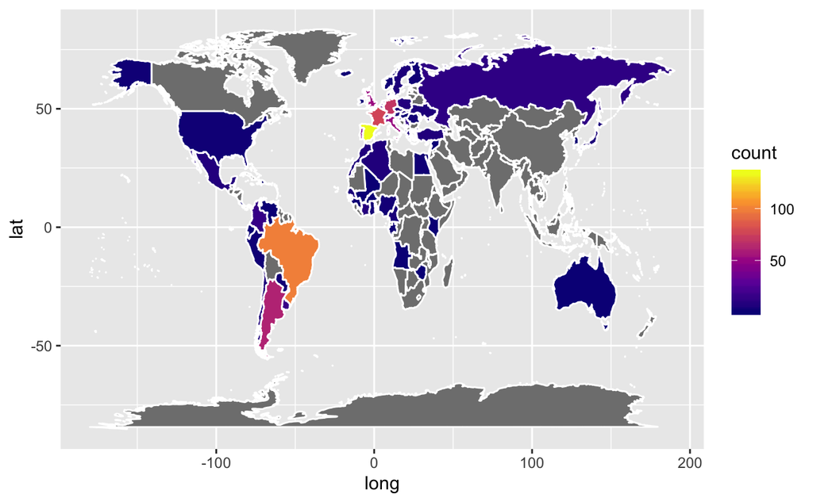

```r
top_soccer_function <-function(x){

  Top <-
  Cleaned_fifa_data %>%
    ### make sure desc overall so the highest overall is the lowest rank
  mutate(rank = rank(desc(Overall))) %>%
  filter(rank < x) %>%
    ### Easier for join
  mutate("region" = Nationality)

  Grouped_top <-
  Top %>%
  ### Group them by their nationality for the graph
  group_by(region) %>%
  summarise(count = n())

  ### Join them
  Joined_top <-
  World_map %>%
  left_join(Grouped_top)

  ### Create the map
  Map<-
    ggplot(Joined_top, aes(x = long, y = lat, group = group)) +
    geom_polygon(aes(fill = count), colour = "white")+
    scale_fill_viridis_c(option = "C")

  ### Produce the Map when the function is run
  return(Map)
}
top_soccer_function(1000)
```

Looking at the map gives us some extremely interesting insights. Even though huge countries like the United States, China, Russia, and Australia have millions of people, they have barely any of the top 1000 players. The top are predominantly from Brazil, Argentina and Europe. This is something that I’m not surprised by, but I would still have expected more variety and in turn, less gray space.

From here on out I wanted to work with the top 1000 players. Knowing each of the top 5 leagues has around 20 teams and 11 players start each game, 1000 gives us a pretty good breadth of talent across the board.

```r
Top <-
  Cleaned_fifa_data %>%
    ### make sure desc overall so the highest overall is the lowest rank
  mutate(rank = rank(desc(Overall))) %>%
  filter(rank < 1000)
```

I also wanted to look at the different position groups and see if things like wage varied across the group. Furthermore, most clubs play a 4-3-3 with a goalie, so I wanted to see how the distribution of the player groups looked.

```r
Position_data <-
  Top %>%
  ### Change each position into one of three categories
  mutate(Position = if_else(Position %in% c("ST", "LF", "RF", "LW", "RW", "RS", "LS", "CF"), "Attack", Position)) %>%
  mutate(Position = if_else(Position %in% c("CM", "LM", "RM", "LCM", "RCM", "CAM", "CDM", "LDM", "RDM", "LAM", "RAM"), "Midfield", Position)) %>%
  mutate(Position = if_else(Position %in% c("CB", "LB", "RB", "LWB", "RWB", "LCB", "RCB", "GK"), "Defense", Position))
Position_data
```

| Name | Age | Nationality | Overall | Potential | Club | Value | Wage | Foot | Weak Foot | Skill Moves | Work Rate | Position | Height | Weight | Crossing | Finishing | HeadingAccuracy | ShortPassing | Volleys | Dribbling | Curve | FKAccuracy | LongPassing | BallControl | Acceleration | SprintSpeed | Agility | Reactions | Balance | … |
| --- | --- | --- | --- | --- | --- | --- | --- | --- | --- | --- | --- | --- | --- | --- | --- | --- | --- | --- | --- | --- | --- | --- | --- | --- | --- | --- | --- | --- | --- | --- |
| L. Messi | 31 | Argentina | 94 | 94 | FC Barcelona | 110.5 | 565 | Left | 4 | 4 | Medium/ Medium | Attack | 170.18 | 159 | 84 | 95 | 70 | 90 | 86 | 97 | 93 | 94 | 87 | 96 | 91 | 86 | 91 | 95 | 95 | … |
| Cristiano Ronaldo | 33 | Portugal | 94 | 94 | Juventus | 77.0 | 405 | Right | 4 | 5 | High/ Low | Attack | 187.96 | 183 | 84 | 94 | 89 | 81 | 87 | 88 | 81 | 76 | 77 | 94 | 89 | 91 | 87 | 96 | 70 | … |
| Neymar Jr | 26 | Brazil | 92 | 93 | Paris Saint-Germain | 118.5 | 290 | Right | 5 | 5 | High/ Medium | Attack | 175.26 | 150 | 79 | 87 | 62 | 84 | 84 | 96 | 88 | 87 | 78 | 95 | 94 | 90 | 96 | 94 | 84 | … |
| De Gea | 27 | Spain | 91 | 93 | Manchester United | 72.0 | 260 | Right | 3 | 1 | Medium/ Medium | Defense | 193.04 | 168 | 17 | 13 | 21 | 50 | 13 | 18 | 21 | 19 | 51 | 42 | 57 | 58 | 60 | 90 | 43 | … |
| K. De Bruyne | 27 | Belgium | 91 | 92 | Manchester City | 102.0 | 355 | Right | 5 | 4 | High/ High | Midfield | 180.34 | 154 | 93 | 82 | 55 | 92 | 82 | 86 | 85 | 83 | 91 | 91 | 78 | 76 | 79 | 91 | 77 | … |
| E. Hazard | 27 | Belgium | 91 | 91 | Chelsea | 93.0 | 340 | Right | 4 | 4 | High/ Medium | Attack | 172.72 | 163 | 81 | 84 | 61 | 89 | 80 | 95 | 83 | 79 | 83 | 94 | 94 | 88 | 95 | 90 | 94 | … |
| L. Modri_ | 32 | Croatia | 91 | 91 | Real Madrid | 67.0 | 420 | Right | 4 | 4 | High/ High | Midfield | 172.72 | 146 | 86 | 72 | 55 | 93 | 76 | 90 | 85 | 78 | 88 | 93 | 80 | 72 | 93 | 90 | 94 | … |
| L. Su\xe0rez | 31 | Uruguay | 91 | 91 | FC Barcelona | 80.0 | 455 | Right | 4 | 3 | High/ Medium | Attack | 182.88 | 190 | 77 | 93 | 77 | 82 | 88 | 87 | 86 | 84 | 64 | 90 | 86 | 75 | 82 | 92 | 83 | … |
| Sergio Ramos | 32 | Spain | 91 | 91 | Real Madrid | 51.0 | 380 | Right | 3 | 3 | High/ Medium | Defense | 182.88 | 181 | 66 | 60 | 91 | 78 | 66 | 63 | 74 | 72 | 77 | 84 | 76 | 75 | 78 | 85 | 66 | … |
| J. Oblak | 25 | Slovenia | 90 | 93 | Atl_tico Madrid | 68.0 | 94 | Right | 3 | 1 | Medium/ Medium | Defense | 187.96 | 192 | 13 | 11 | 15 | 29 | 13 | 12 | 13 | 14 | 26 | 16 | 43 | 60 | 67 | 86 | 49 | … |

[output cut: 884 more lines]

```r
### This will create a data table with each position and their count
Grouped_Position_data <-
  Position_data %>%
  group_by(Position) %>%
  summarise(count = n())
Grouped_Position_data
```

| Position | count |
| --- | --- |
| Attack | 183 |
| Defense | 350 |
| Midfield | 361 |

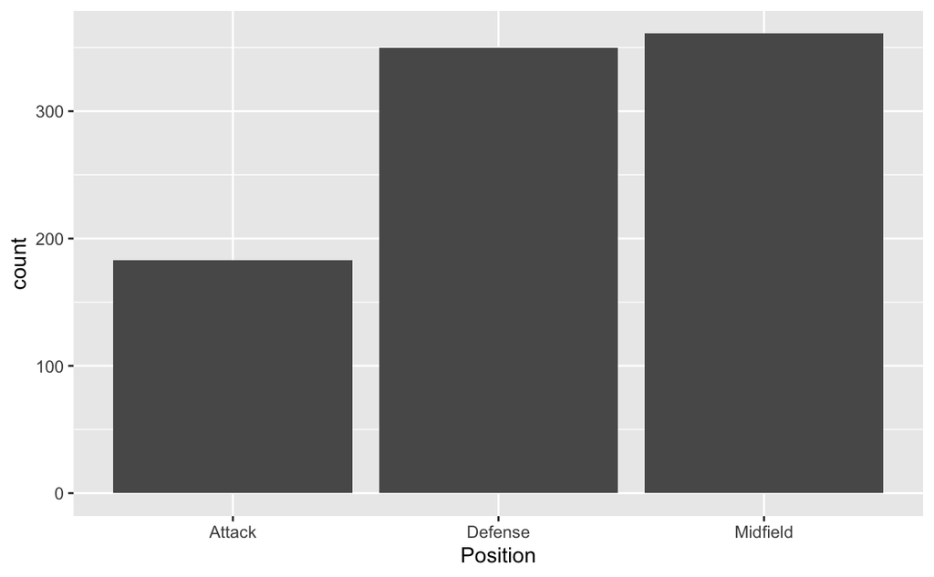

```r
### Create a boxplot
ggplot(data=Grouped_Position_data,aes(x=Position,y=count )) +
  geom_bar(stat = 'identity',position = 'stack', width = .9)
```

I am actually quite surprised by this graphic. I figured FIFA may tailor their ratings to attacking players. I also thought the distribution may be a little more equal than this, even with Defense getting a boost from GK being considered a defender. However, maybe they consider players that play both attack and midfield midfielders.

I then wanted to see how old the top players were and if this varied by position.

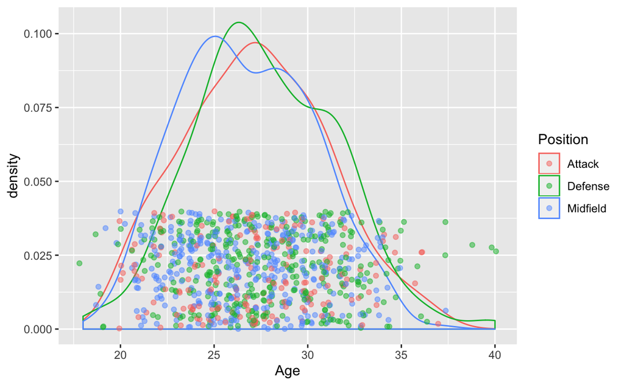

```r
ggplot( data = Position_data, aes(x = Age)) +
  geom_density() +
  aes(colour = Position) +
  ### Add jitter to see actual distribution
  geom_point(alpha = 0.5, aes(y = 0.02),
             position = position_jitter(height = 0.02))
```

This graph makes a lot of sense. We would expect the best players to be in their prime and that usually is correlated with the mid 20s. Interestingly we see some really old defenders and really young defenders in the jitter. Defenders can afford to be on the slower side, so them being old makes sense. However, the younger ones surprise me but seem like outliers as we see the distribution lines are much higher for attack and midfield at the younger ages.

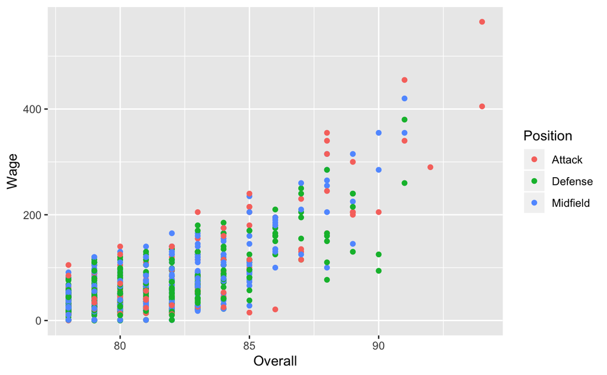

```r
### Make a scatter plot showing wage and Overall
ggplot(data = Position_data, aes(x = Overall,y = Wage))+
  geom_point() + aes(colour = Position)
```

Finally, I was interested to see if a players wage is correlated with their overall FIFA rating. As seen in the plot above there is a clear upward trend. Also, we see that Attackers generally make more at a similar overall and defenders make the least. This makes sense as fans want to see goals and the top attackers make the largest impact. Lastly, there appears to be a clear floor at zero which makes sense because you can not pay a player less than that.

Overall, I would say I learned a lot about the best FIFA players. They are generally from Europe and South America. Most are defenders or midfielders, yet the attackers get paid more. They are generally in their mid 20s and the better they are the more they get paid.